# Operating Characteristics of the Tier-2 De-biased Gate

Estimation/coverage head-to-head against the Tier-1 bootstrap, on the León (2024) Table 2 design

Author

Larry León

Published

June 12, 2026

> **Status — smoke test.** This is the development configuration of the simulation: tiny counts to wire the pipeline end-to-end on a single M1 cell before scaling up. Every tunable lives in the setup chunk (Section 2); the counts (`n_sims`, `nb_boots`, `gate_draws`) are the only things to change to move from smoke test to production. Results run live — no `saveRDS`/`readRDS` caching.

# 1 What this evaluates

The **Tier-2 de-biased gate** (`fs_debias_gate()`, surfaced through `forestsearch(debias_gate = TRUE)`) is a refit-free multiplier-bootstrap approximation of León’s post-selection bias correction, with an infinitesimal-jackknife (IJ) confidence interval. To first order its point estimate equals León’s Eq. 7 correction and its interval equals León’s IJ variance, the only approximation being the per-subgroup `dfbeta` linearization.

This document turns the single-trial validation into operating characteristics by re-running the León (2024) estimation/coverage design and recording, **per replicate on the same data and the same selected subgroup**:

- **oracle** $\hat\theta(H)$ — refit on the *true* harm subgroup;
- **naive** $\hat\theta(\hat H)$ — plugin on the identified subgroup;
- **Tier-1** $\hat\theta^{*}(\hat H)$ — full nonparametric bootstrap bias-correction (`forestsearch_bootstrap_dofuture()`, León Eq. 7, the `H2` variant accounting for both bias sources) with its IJ interval;
- **Tier-2** $\tilde\theta(\hat H)$ — the de-biased gate with its IJ interval.

Each is compared to three truth targets: the per-replicate **oracle** estimate, the controlled direct effect $\theta^{\ddagger}$ (CDE), and the marginal subgroup hazard ratio $\theta^{\dagger}$. The two outputs are (1) the León Table-2-layout estimation/coverage table with a Tier-2 block, and (2) the paired Tier-1$\leftrightarrow$Tier-2 agreement panel. For `consistency` (a fixed candidate family) that panel is the most direct empirical check of the leading-order correspondence; for `dina`/`grf` the bootstrap regenerates the family per resample, so the panel instead measures the family-regeneration gap between the unconditional (Tier-1) and conditional-on-family (Tier-2) estimands.

# 2 Setup — all knobs

```r
# NOTE: forestsearch must be INSTALLED (devtools::install()), not load_all():
# the doFuture multisession workers spawn separate R processes that only see the
# installed package.
library(forestsearch)
library(survival)
library(data.table)
library(gt)
library(ggplot2)
library(foreach)
library(doFuture)
library(future)

# ── Smoke-test counts (the only knobs to change for production) ────────────
n_sims       <- 20L       # simulated trials                (prod: 1000 -> 20000)
diag_mode    <- FALSE     # DIAGNOSTIC: TRUE caps the run to 5 replicates and relays each
                          # worker's forestsearch() error (otherwise swallowed by the inner
                          # tryCatch).  Set FALSE for a real run.
nb_boots     <- 300L       # Tier-1 nonparametric bootstraps (prod: 200 -> 500)
gate_draws   <- 2000L     # Tier-2 multiplier draws         (keep ~2000)

run_smoke    <- TRUE      # master flag; FALSE short-circuits the run loop

# Scale-up scenarios for the timing projection (n_sims, nb_boots). Edit freely.
proj_scenarios <- list(
  c(n_sims = 100L,  nb_boots = 50L),
  c(n_sims = 500L,  nb_boots = 300L),
  c(n_sims = 1000L, nb_boots = 500L)
)

# ── DGM: León M1 cell (GBSG AFT super-population, alt hypothesis) ───────────
dgm_model       <- "alt"
target_hr_harm  <- 2.0    # calibrate k_inter to this Cox HR in the harm subgroup
n_sample        <- 700L   # M1 sample size
analysis_time   <- 84     # administrative censoring (months)
cens_adjust     <- log(1.5)
n_super         <- 5000L

# ── Subgroup-identification method ─────────────────────────────────────────
# The Tier-1 bootstrap (H2, León Eq.7) re-runs whichever engine fs.est used,
# regenerating the candidate family on each resample, so the Tier-1-vs-Tier-2
# comparison is produced for every engine.  Interpretation differs by engine:
# for "consistency" the family is fixed, so Tier-1 and the gate target the same
# estimand and should agree (the dfbeta-linearisation check); for "dina"/"grf"
# the family regenerates per resample, so Tier-1 is the *unconditional*
# comparator against the gate's *conditional-on-family* estimate, and a
# Tier-1<->Tier-2 gap is the family-regeneration signal, not an error.
subgroup_method <- "grf"  # "consistency" | "dina" | "grf"
grf_selection   <- "frontier"      # only if subgroup_method == "grf": "tree" | "frontier"
grf_select_statistic <- "effect"   # only if grf frontier: "dr" | "effect" (no-op for tree)
grf_depth       <- 2L              # GRF policy-tree depth / max frontier conjunctions
dmin.grf        <- 0.0             # GRF DR-score screening floor
dina_args       <- list()          # extra args forwarded to the DINA selector (dina_args =)
dina_select_statistic <- "effect"  # only if subgroup_method == "dina": "dina" | "effect"

# ── Search configuration (León tuning; resample identification) ────────────
consistency_method <- "resample"   # decided: resample identification (the new default)
sg_focus           <- "eff"        # -> "hr": highest consistency rate, ties by effect
# Gate re-selection is no longer set explicitly: forestsearch() derives it from
# sg_focus (consistency + "eff" -> "maxcons"), reproducing the legacy explicit
# value while staying faithful per engine.  Override via `reselection =` in
# debias_gate_args (advanced use only).
selection_rule     <- "neighborhood"  # *MaxSG/*MinSG band rule (inert for sg_focus = "eff")
hr_threshold       <- 1.0
hr_consistency     <- 1.0
pconsistency       <- 0.90
fs_splits          <- 400L         # moot under "resample" (closed-form, not literal split)
maxk               <- 2L
n_min              <- 60L
d0_min             <- 12L
d1_min             <- 0L
use_lasso          <- FALSE
use_dina           <- FALSE
use_grf            <- TRUE         # FALSE = LASSO-only (fast, "FSl"); set TRUE for "FSlg"
use_twostage       <- TRUE

fs_conf_force      <- c("meno == 0")   # premenopausal (raw analog of z3 == 1)
fs_conf.cont_jcuts <- list(er = 10)     # J-quantile grid on raw ER (analog of z1; now meaningful, ER is continuous)

# ── Column names emitted by simulate_from_dgm() ────────────────────────────
outcome_name   <- "y_sim"
event_name     <- "event_sim"
treat_name     <- "treat_sim"
id_name        <- "id"
harm_col       <- "flag_harm"
# Raw GBSG covariate candidates (as in a real analysis): forestsearch discovers
# its own cuts. Continuous -> er, age, pgr, nodes, size; categorical -> meno (0/1),
# grade (1/2/3). The pre-dichotomized z1..z5 are NOT used. The true harm subgroup
# (er <= 25th pct & meno == 0) must be re-discovered from these raw variables.
confounders_base <- c("er", "age", "meno", "pgr", "nodes", "size", "grade")

# ── Reproducibility / parallelism ──────────────────────────────────────────
seed_base  <- 8316951L
n_workers  <- ceiling(0.95*max(1L, min(parallel::detectCores(logical = FALSE) - 1L)))
z975       <- qnorm(0.975)

cat(sprintf("Smoke test: method=%s%s, n_sims=%d, nb_boots=%d, gate_draws=%d, workers=%d\n",
            subgroup_method,
            if (identical(subgroup_method, "grf")) paste0("/", grf_selection) else "",
            n_sims, nb_boots, gate_draws, n_workers))
```

```
Smoke test: method=grf/frontier, n_sims=20, nb_boots=300, gate_draws=2000, workers=121
```

# 3 Build the DGM and read off the truth targets

```r
k_inter <- calibrate_k_inter(target_hr_harm = target_hr_harm,
                             model = dgm_model, use_ahr = FALSE)
dgm <- setup_gbsg_dgm(model = dgm_model, k_inter = k_inter,
                      n_super = n_super, seed = seed_base)
dgm <- compute_dgm_cde(dgm)   # attaches CDE (theta-ddagger) targets

`%||%` <- function(a, b) if (is.null(a) || length(a) == 0 || all(is.na(a))) b else a

# Fixed (population) truth targets, read defensively from the DGM object.
truth <- list(
  hr_causal   = dgm$hr_causal   %||% NA_real_,                 # overall causal HR
  marg_H      = dgm$hr_H_true   %||% NA_real_,                 # theta-dagger (H)
  marg_Hc     = dgm$hr_Hc_true  %||% NA_real_,                 # theta-dagger (Hc)
  cde_H       = dgm$cde_H       %||% (dgm$hazard_ratios$CDE_harm    %||% NA_real_),  # theta-ddagger (H)
  cde_Hc      = dgm$cde_Hc      %||% (dgm$hazard_ratios$CDE_no_harm %||% NA_real_)   # theta-ddagger (Hc)
)

cat("DGM truth targets (population):\n")
```

```
DGM truth targets (population):
```

```r
cat(sprintf("  overall causal HR      : %.3f\n", truth$hr_causal))
```

```
  overall causal HR      : 0.722
```

```r
cat(sprintf("  theta-dagger  H / Hc   : %.3f / %.3f\n", truth$marg_H, truth$marg_Hc))
```

```
  theta-dagger  H / Hc   : 2.000 / 0.661
```

```r
cat(sprintf("  theta-ddagger H / Hc   : %.3f / %.3f\n", truth$cde_H,  truth$cde_Hc))
```

```
  theta-ddagger H / Hc   : 2.400 / 0.585
```

# 4 Per-replicate paired recorder

For each simulated trial: identify $\hat H$ and obtain the naive + Tier-2 gate in one `forestsearch()` call, run the Tier-1 bootstrap on the *same* fit (inheriting `consistency_method = "resample"`), and refit the oracle on the true subgroup. Inner `forestsearch()`/bootstrap parallelism is forced sequential because the outer loop already parallelises across trials.

```r
# Cox HR + delta-method 95% CI on a subset (for the per-replicate oracle).
# Guards against separation: non-finite coef/SE (the "coefficient may be
# infinite" case) returns a clean NA triple rather than Inf/NaN bounds.
.cox_hr_ci <- function(df) {
  if (sum(df[[event_name]]) < 5L || length(unique(df[[treat_name]])) < 2L)
    return(c(est = NA_real_, lo = NA_real_, hi = NA_real_))
  fml <- stats::as.formula(
    sprintf("survival::Surv(%s, %s) ~ %s", outcome_name, event_name, treat_name))
  fit <- tryCatch(survival::coxph(fml, data = df), error = function(e) NULL)
  if (is.null(fit)) return(c(est = NA_real_, lo = NA_real_, hi = NA_real_))
  b  <- unname(stats::coef(fit)[1])
  v  <- unname(suppressWarnings(diag(stats::vcov(fit))[1]))  # unname: else lo/hi inherit coef name -> oH["lo"] = NA
  se <- if (is.finite(v) && v > 0) sqrt(v) else NA_real_
  if (!is.finite(b) || !is.finite(se))
    return(c(est = NA_real_, lo = NA_real_, hi = NA_real_))
  c(est = exp(b), lo = exp(b - z975 * se), hi = exp(b + z975 * se))
}

# Classification of the identified subgroup against the true harm flag.
# sg_hat is grp.consistency$sg.harm.id: a per-subject 0/1 vector, length
# nrow(df), aligned to the input rows (clean on the consistency result; the
# GRF-object naming collision does not apply here).
.classify <- function(sg_hat, truth) {
  out <- c(sens = NA_real_, spec = NA_real_, ppv = NA_real_, npv = NA_real_)
  if (is.null(sg_hat) || length(sg_hat) != length(truth)) return(out)
  sg_hat <- as.integer(sg_hat); truth <- as.integer(truth)
  tp <- sum(sg_hat == 1 & truth == 1); fp <- sum(sg_hat == 1 & truth == 0)
  fn <- sum(sg_hat == 0 & truth == 1); tn <- sum(sg_hat == 0 & truth == 0)
  out["sens"] <- if (tp + fn > 0) tp / (tp + fn) else NA_real_
  out["spec"] <- if (tn + fp > 0) tn / (tn + fp) else NA_real_
  out["ppv"]  <- if (tp + fp > 0) tp / (tp + fp) else NA_real_
  out["npv"]  <- if (tn + fn > 0) tn / (tn + fn) else NA_real_
  out
}

# One all-NA record (returned on failure so the loop never aborts a cell).
.na_record <- function(sim_id) data.frame(
  sim_id = sim_id, detected = 0L, gate_ok = 0L, n_sel = NA_integer_,
  n_harm = NA_integer_,
  label = NA_character_, t1_secs = NA_real_, t2_secs = NA_real_, t1_err = NA_character_,
  or_H_est = NA, or_H_lo = NA, or_H_hi = NA,
  or_Hc_est = NA, or_Hc_lo = NA, or_Hc_hi = NA,
  nv_H_est = NA, nv_H_lo = NA, nv_H_hi = NA,
  nv_Hc_est = NA, nv_Hc_lo = NA, nv_Hc_hi = NA,
  t1_H_est = NA, t1_H_lo = NA, t1_H_hi = NA,
  t1_Hc_est = NA, t1_Hc_lo = NA, t1_Hc_hi = NA,
  t2_H_est = NA, t2_H_lo = NA, t2_H_hi = NA, t2_H_se_ij = NA,
  t2_Hc_est = NA, t2_Hc_lo = NA, t2_Hc_hi = NA, t2_Hc_se_ij = NA,
  t2_harm_flag = NA_integer_, ij_source = NA_character_,
  sens = NA_real_, spec = NA_real_, ppv = NA_real_, npv = NA_real_,
  stringsAsFactors = FALSE)

record_replicate <- function(sim_id) {
  rec <- .na_record(sim_id)

  df <- tryCatch(
    simulate_from_dgm(dgm, n = n_sample, analysis_time = analysis_time,
                      cens_adjust = cens_adjust, seed = seed_base + sim_id),
    error = function(e) NULL)
  if (is.null(df)) return(rec)
  df[[id_name]] <- seq_len(nrow(df))
  confs <- intersect(confounders_base, names(df))

  # ---- Identification + naive + Tier-2 gate (single forestsearch call) -----
  # Args common to every method, plus a method-specific block.  Consistency-only
  # tuning (LASSO/two-stage/forced cuts/maxk) is NOT forwarded to DINA/GRF, which
  # have their own candidate enumeration; all methods search the same confs.
  base_args <- list(
    df.analysis     = df,
    outcome.name    = outcome_name, event.name = event_name,
    treat.name      = treat_name,   id.name    = id_name,
    flag_harm.name  = harm_col,     confounders.name = confs,
    is.RCT          = TRUE,         seedit = seed_base + sim_id,
    quiet           = TRUE,         # suppress the "De-biased gate: ..." cat()
    sg_focus        = sg_focus,
    subgroup_method = subgroup_method,
    hr.threshold    = hr_threshold, hr.consistency = hr_consistency,
    pconsistency.threshold = pconsistency, n.min = n_min,
    selection_rule  = selection_rule,   # governs *MaxSG/*MinSG band (search + gate)
    parallel_args   = list(plan = "sequential"),   # outer loop owns parallelism
    debias_gate     = TRUE,
    debias_gate_args = list(ci_method = "ij", draws = gate_draws,
                            include_complement = TRUE)  # reselection derived from sg_focus
  )
  method_args <- switch(
    subgroup_method,
    consistency = list(
      consistency_method = consistency_method,
      use_lasso = use_lasso, use_grf = use_grf, use_twostage = use_twostage,
      use_dina = use_dina,
      conf_force = fs_conf_force, conf.cont_jcuts = fs_conf.cont_jcuts,
      fs.splits = fs_splits, maxk = maxk, d0.min = d0_min, d1.min = d1_min),
    dina = list(dina_select_statistic = dina_select_statistic,
                dina_args             = dina_args),
    grf  = list(grf_selection = grf_selection, grf_depth = grf_depth,
                dmin.grf = dmin.grf, grf_select_statistic = grf_select_statistic),
    stop("unknown subgroup_method: ", subgroup_method)
  )

  t2_t0 <- proc.time()[3]
  fs.est <- tryCatch(do.call(forestsearch, c(base_args, method_args)),
                     error = function(e) {
                       if (isTRUE(get0("diag_mode", ifnotfound = FALSE)))
                         warning(sprintf("FS-ERR sim %d: %s", sim_id,
                                         conditionMessage(e)), call. = FALSE)
                       NULL
                     })
  rec$t2_secs <- proc.time()[3] - t2_t0
  if (is.null(fs.est)) return(rec)

  # Detection is METHOD-AGNOSTIC (a subgroup was identified), independent of
  # whether the Tier-2 gate produced a CI; gate availability is tracked
  # separately in gate_ok so a gate failure never masks a true detection.
  g     <- fs.est$debias_gate
  found <- !is.null(fs.est$sg.harm)
  rec$detected <- as.integer(found)
  if (!found) return(rec)
  rec$gate_ok <- as.integer(!is.null(g))

  if (!is.null(g)) {
    rec$label <- g$selected_label %||% NA_character_
    rec$n_sel <- g$n_selected      %||% NA_integer_
    rec$t2_harm_flag <- as.integer(isTRUE(g$harm_flag))
    rec$ij_source    <- g$debiased$ij_source %||% NA_character_
    rec$nv_H_est <- g$naive$est;    rec$nv_H_lo <- g$naive$lower;    rec$nv_H_hi <- g$naive$upper
    rec$t2_H_est <- g$debiased$est; rec$t2_H_lo <- g$debiased$lower; rec$t2_H_hi <- g$debiased$upper
    rec$t2_H_se_ij <- g$debiased$se_ij %||% NA_real_
    if (is.list(g$complement) && !is.null(g$complement$debiased)) {
      rec$nv_Hc_est <- g$complement$naive$est
      rec$nv_Hc_lo  <- g$complement$naive$lower
      rec$nv_Hc_hi  <- g$complement$naive$upper
      rec$t2_Hc_est <- g$complement$debiased$est
      rec$t2_Hc_lo  <- g$complement$debiased$lower
      rec$t2_Hc_hi  <- g$complement$debiased$upper
      rec$t2_Hc_se_ij <- g$complement$debiased$se_ij %||% NA_real_
    }
  }

  # ---- Classification of Ĥ against the true harm flag ----------------------
  cl <- .classify(fs.est$grp.consistency$sg.harm.id, df[[harm_col]])
  rec$sens <- cl["sens"]; rec$spec <- cl["spec"]
  rec$ppv  <- cl["ppv"];  rec$npv <- cl["npv"]
  rec$n_harm <- sum(fs.est$grp.consistency$sg.harm.id == 1L, na.rm = TRUE)

  # ---- Tier-1 bootstrap (H2 = León Eq.7) -----------------------------------
  # forestsearch_bootstrap_dofuture re-runs whichever engine fs.est used (via
  # fs.est$args_call_all), regenerating the candidate family on each resample.
  # For "consistency" the family is fixed, so Tier-1 and the Tier-2 gate target
  # the same estimand; for "dina"/"grf" the family regenerates per resample, so
  # Tier-1 is the *unconditional* comparator against the gate's
  # *conditional-on-family* estimate -- a Tier-1<->Tier-2 gap there is the
  # family-regeneration signal, not an error.  If an engine cannot return H2 the
  # call falls back to NULL (t1_* stay NA) and the message is captured in t1_err.
  if (subgroup_method %in% c("consistency", "dina", "grf")) {
    t1_t0 <- proc.time()[3]; t1_err <- NA_character_
    boot <- tryCatch(
      forestsearch_bootstrap_dofuture(
        fs.est, nb_boots = nb_boots, seed = seed_base + sim_id,
        parallel_args = list(plan = "sequential")),
      error = function(e) { t1_err <<- conditionMessage(e); NULL })
    rec$t1_secs <- proc.time()[3] - t1_t0
    rec$t1_err  <- t1_err
    if (!is.null(boot) && !is.null(boot$H_estimates)) {
      he <- boot$H_estimates                     # H2 = León Eq.7 (both bias sources)
      rec$t1_H_est <- he$H2; rec$t1_H_lo <- he$H2_lower; rec$t1_H_hi <- he$H2_upper
    }
    if (!is.null(boot) && !is.null(boot$Hc_estimates)) {
      hce <- boot$Hc_estimates
      rec$t1_Hc_est <- hce$H2; rec$t1_Hc_lo <- hce$H2_lower; rec$t1_Hc_hi <- hce$H2_upper
    }
  }

  # ---- Oracle: refit on the TRUE harm subgroup of this trial ---------------
  oH  <- .cox_hr_ci(df[df[[harm_col]] == 1, , drop = FALSE])
  oHc <- .cox_hr_ci(df[df[[harm_col]] == 0, , drop = FALSE])
  rec$or_H_est <- oH["est"];   rec$or_H_lo <- oH["lo"];   rec$or_H_hi <- oH["hi"]
  rec$or_Hc_est <- oHc["est"]; rec$or_Hc_lo <- oHc["lo"]; rec$or_Hc_hi <- oHc["hi"]

  rec
}
```

# 5 Run the simulation

```r
results <- NULL
if (run_smoke) {
  plan("sequential"); gc()
  plan("multisession", workers = n_workers)

  t_all <- proc.time()[3]
  results <- foreach(
    s = seq_len(if (isTRUE(diag_mode)) min(n_sims, 5L) else n_sims),
    .combine = rbind, .errorhandling = "remove",
    .options.future = list(packages = c("forestsearch", "survival", "data.table"),
                           seed = TRUE)
  ) %dofuture% {
    record_replicate(s)
  }
  elapsed <- proc.time()[3] - t_all

  plan("sequential"); gc()   # release workers between phases

  cat(sprintf("Completed %d/%d replicates in %.1f s (%.1f s/replicate).\n",
              sum(results$detected, na.rm = TRUE), n_sims, elapsed,
              elapsed / max(1L, n_sims)))
  cat(sprintf("Mean wall-clock: Tier-2 gate %.3f s vs Tier-1 bootstrap %.2f s (B=%d).\n",
              mean(results$t2_secs, na.rm = TRUE),
              mean(results$t1_secs, na.rm = TRUE), nb_boots))

  # Surface any (otherwise-swallowed) Tier-1 bootstrap error(s) on detected reps.
  t1_tried <- sum(results$detected == 1L, na.rm = TRUE)
  t1_fail  <- sum(results$detected == 1L & is.na(results$t1_H_est), na.rm = TRUE)
  if (t1_fail > 0L) {
    cat(sprintf("Tier-1 bootstrap returned no estimate on %d of %d detected replicate(s).\n",
                t1_fail, t1_tried))
    errs <- unique(stats::na.omit(results$t1_err))
    if (length(errs))
      cat("Distinct Tier-1 error(s):\n", paste0("  - ", errs, collapse = "\n"), "\n", sep = "")
  }
}
```

```
Completed 20/20 replicates in 1349.9 s (67.5 s/replicate).
Mean wall-clock: Tier-2 gate 5.044 s vs Tier-1 bootstrap 1312.72 s (B=300).
```

# 6 Timing and scale-up projection

Tier-2 cost per replicate is essentially fixed (one fit + the multiplier draws, independent of `nb_boots`); Tier-1 cost scales **linearly** with `nb_boots` (it re-runs the whole search once per bootstrap). The projection below uses the measured per-replicate times, assumes Tier-1 runs only on detected replicates, and divides by the worker count for an idealized wall-clock.

```r
if (run_smoke && !is.null(results)) {
  t2_mean  <- mean(results$t2_secs, na.rm = TRUE)              # forestsearch + gate, per rep
  t1_mean  <- mean(results$t1_secs, na.rm = TRUE)              # bootstrap, per (detected) rep
  per_boot <- t1_mean / nb_boots                               # cost of one bootstrap re-search
  det_rate <- mean(results$detected, na.rm = TRUE)

  fmt_hm <- function(sec) {
    if (!is.finite(sec)) return("\u2014")                       # no timing available
    h <- floor(sec / 3600); m <- round((sec - 3600 * h) / 60)
    if (h >= 1) sprintf("%d h %02d m", h, m) else sprintf("%d m", round(sec / 60))
  }
  # Per-rep totals and wall-clock under the same n_workers used here.
  proj_row <- function(ns, B) {
    t1_rep   <- per_boot * B
    t1_term  <- if (is.finite(t1_rep)) det_rate * t1_rep else 0  # no Tier-1 timing (e.g. 0 detections) -> Tier-2 only
    cpu_sec  <- ns * (t2_mean + t1_term)                       # Tier-2 all reps; Tier-1 detected only
    wall_id  <- cpu_sec / n_workers                            # idealized (perfect parallelism)
    data.frame(n_sims = ns, B = B,
               t2_rep_s = round(t2_mean, 1), t1_rep_s = round(t1_rep, 0),
               cpu_hours = round(cpu_sec / 3600, 1),
               wall_ideal = fmt_hm(wall_id),
               wall_real_1.3x = fmt_hm(1.3 * wall_id),
               stringsAsFactors = FALSE)
  }
  cur <- proj_row(n_sims, nb_boots)
  scn <- do.call(rbind, lapply(proj_scenarios,
                               function(s) proj_row(s[["n_sims"]], s[["nb_boots"]])))
  tab <- rbind(cbind(Scenario = "current run", cur),
               cbind(Scenario = "projection",  scn))

  cat(sprintf(
    "Current run: %d reps in %.0f s on %d workers. Per rep: Tier-2 %.1f s, Tier-1 %.0f s (B=%d, ~%.1f s/bootstrap). Detection %.0f%%.\n",
    n_sims, elapsed, n_workers, t2_mean, t1_mean, nb_boots, per_boot, 100 * det_rate))

  gt(tab) |>
    tab_header(title = "Wall-clock projection",
               subtitle = sprintf("Measured on this run \u00b7 %d workers \u00b7 detection %.0f%%",
                                  n_workers, 100 * det_rate)) |>
    cols_label(n_sims = "sims", B = "boots", t2_rep_s = "Tier-2/rep (s)",
               t1_rep_s = "Tier-1/rep (s)", cpu_hours = "CPU-hours",
               wall_ideal = "wall (ideal)", wall_real_1.3x = "wall (~1.3\u00d7)") |>
    tab_footnote(footnote = md(paste(
      "Tier-2/rep is fixed; Tier-1/rep = (per-bootstrap cost) \u00d7 boots.",
      "CPU-hours = sims \u00d7 (Tier-2/rep + detection \u00d7 Tier-1/rep).",
      "`wall (ideal)` divides by workers assuming perfect parallelism;",
      "`~1.3\u00d7` adds a rule-of-thumb overhead (pool spin-up, memory contention at high worker counts).")))
}
```

```
Current run: 20 reps in 1350 s on 121 workers. Per rep: Tier-2 5.0 s, Tier-1 1313 s (B=300, ~4.4 s/bootstrap). Detection 100%.
```

Wall-clock projection

Measured on this run · 121 workers · detection 100%

| Scenario | sims | boots | Tier-2/rep (s) | Tier-1/rep (s) | CPU-hours | wall (ideal) | wall (~1.3×) |
| --- | --- | --- | --- | --- | --- | --- | --- |
| current run | 20 | 300 | 5 | 1313 | 7.3 | 4 m | 5 m |
| projection | 100 | 50 | 5 | 219 | 6.2 | 3 m | 4 m |
| projection | 500 | 300 | 5 | 1313 | 183.0 | 1 h 31 m | 1 h 58 m |
| projection | 1000 | 500 | 5 | 2188 | 609.1 | 5 h 02 m | 6 h 33 m |

Tier-2/rep is fixed; Tier-1/rep = (per-bootstrap cost) × boots. CPU-hours = sims × (Tier-2/rep + detection × Tier-1/rep). `wall (ideal)` divides by workers assuming perfect parallelism; `~1.3×` adds a rule-of-thumb overhead (pool spin-up, memory contention at high worker counts).

# 7 Estimation / coverage table (León Table 2 layout + Tier-2)

```r
# All summaries are finite-only: non-finite estimates/bounds (e.g. from Cox
# separation or an unstable small-B IJ) are dropped so a single blow-up cannot
# dominate a mean.
.cover <- function(target, lo, hi) {
  target <- rep_len(target, length(lo))   # recycle scalar targets (CDE/marginal) to n reps
  ok <- is.finite(target) & is.finite(lo) & is.finite(hi)
  if (!any(ok)) return(NA_real_)
  mean(target[ok] >= lo[ok] & target[ok] <= hi[ok])
}
.pbias <- function(est, target) {
  d <- (est - target) / target; d <- d[is.finite(d)]
  if (!length(d)) return(NA_real_)
  100 * mean(d)
}
# HR-scale SD implied by log-scale CI bounds (uniform across estimators).
.sd_hat <- function(est, lo, hi) {
  se_log <- (log(hi) - log(lo)) / (2 * z975)
  v <- est * se_log; v <- v[is.finite(v)]
  if (!length(v)) return(NA_real_)
  mean(v)
}
.mfin <- function(x) { x <- x[is.finite(x)]; if (length(x)) mean(x) else NA_real_ }
.sdfin <- function(x) { x <- x[is.finite(x)]; if (length(x) > 1L) sd(x) else NA_real_ }

# Build one block (H or Hc): four estimator rows against three targets.
build_block <- function(r, suffix, tgt_cde, tgt_marg) {
  est_keys <- c(oracle = "or", naive = "nv", `Tier-1` = "t1", `Tier-2` = "t2")
  or_est <- r[[paste0("or_", suffix, "_est")]]   # per-replicate oracle target
  rows <- lapply(names(est_keys), function(lab) {
    k  <- est_keys[[lab]]
    e  <- r[[paste0(k, "_", suffix, "_est")]]
    lo <- r[[paste0(k, "_", suffix, "_lo")]]
    hi <- r[[paste0(k, "_", suffix, "_hi")]]
    len <- hi - lo; len <- len[is.finite(len)]
    data.frame(
      Estimator = lab,
      n       = sum(is.finite(e)),
      Avg     = .mfin(e),
      SD      = .sdfin(e),
      SD_hat  = .sd_hat(e, lo, hi),
      Len_med = if (length(len)) stats::median(len) else NA_real_,
      Length  = if (length(len)) mean(len) else NA_real_,
      b_oracle = .pbias(e, or_est),
      b_cde    = .pbias(e, tgt_cde),
      b_marg   = .pbias(e, tgt_marg),
      Cov_oracle = .cover(or_est, lo, hi),
      Cov_cde    = .cover(tgt_cde,  lo, hi),
      Cov_marg   = .cover(tgt_marg, lo, hi),
      stringsAsFactors = FALSE)
  })
  do.call(rbind, rows)
}

if (run_smoke && !is.null(results)) {
  rH  <- results[results$detected == 1, , drop = FALSE]
  blockH  <- build_block(rH, "H",  truth$cde_H,  truth$marg_H)
  blockHc <- build_block(rH, "Hc", truth$cde_Hc, truth$marg_Hc)
  est_tab <- rbind(
    cbind(Block = "Harm  \u0124", blockH),
    cbind(Block = "Complement  \u0124\u1d9c", blockHc)
  )

  det_rate <- mean(results$detected, na.rm = TRUE)
  # Classification + decision + IJ-stability diagnostics (over detected reps).
  cls <- sprintf("sens %.2f \u00b7 spec %.2f \u00b7 PPV %.2f \u00b7 NPV %.2f",
                 .mfin(rH$sens), .mfin(rH$spec), .mfin(rH$ppv), .mfin(rH$npv))
  harm_rate <- mean(rH$t2_harm_flag, na.rm = TRUE)
  ij_ok     <- mean(rH$ij_source == "ij", na.rm = TRUE)

  gt(est_tab, groupname_col = "Block") |>
    tab_header(
      title = "Tier-2 de-biased gate vs Tier-1 bootstrap: estimation & coverage",
      subtitle = sprintf("M1 smoke test \u00b7 n=%d, %d sims, B=%d, draws=%d \u00b7 resample identification",
                         n_sample, n_sims, nb_boots, gate_draws)) |>
    fmt_number(columns = c(Avg, SD, SD_hat, Len_med, Length), decimals = 2) |>
    fmt_number(columns = c(b_oracle, b_cde, b_marg), decimals = 1) |>
    fmt_number(columns = c(Cov_oracle, Cov_cde, Cov_marg), decimals = 2) |>
    cols_label(
      n = "n", Len_med = "Len(med)",
      SD_hat = md("$\\widehat{\\text{SD}}$"),
      b_oracle = md("$b^{\\text{oracle}}$"), b_cde = md("$b^{\\ddagger}$"),
      b_marg = md("$b^{\\dagger}$"),
      Cov_oracle = md("$\\hat{C}^{\\text{oracle}}$"),
      Cov_cde = md("$\\hat{C}^{\\ddagger}$"), Cov_marg = md("$C^{\\dagger}$")) |>
    tab_spanner(label = "Relative bias (%)", columns = c(b_oracle, b_cde, b_marg)) |>
    tab_spanner(label = "95% coverage", columns = c(Cov_oracle, Cov_cde, Cov_marg)) |>
    tab_footnote(footnote = md(sprintf(
      "Detection rate **%.0f%%** of %d sims; gate flags harm in **%.0f%%** of detected reps; IJ variance held (not fallback) in **%.0f%%**. Classification of \u0124 vs true subgroup: %s. Summaries finite-only over detected reps; `n` = finite reps contributing.",
      100 * det_rate, n_sims, 100 * harm_rate, 100 * ij_ok, cls))) |>
    tab_footnote(footnote = md(paste(
      "Targets: $b^{\\text{oracle}}$ vs per-replicate oracle $\\hat\\theta(H)$;",
      "$b^{\\ddagger}$ vs CDE $\\theta^{\\ddagger}$;",
      "$b^{\\dagger}$ vs marginal subgroup HR $\\theta^{\\dagger}$.",
      "`Len(med)` = median CI length (robust to blow-ups); `Length` = mean.",
      "Tier-1 = `H2` (León Eq.7, both bias sources); Tier-2 = de-biased gate, IJ interval.")))
}
```

Tier-2 de-biased gate vs Tier-1 bootstrap: estimation & coverage

M1 smoke test · n=700, 20 sims, B=300, draws=2000 · resample identification

| Estimator | n | Avg | SD | $\widehat{\text{SD}}$ | Len(med) | Length | Relative bias (%) $b^{\text{oracle}}$ | Relative bias (%) $b^{\ddagger}$ | Relative bias (%) $b^{\dagger}$ | 95% coverage $\hat{C}^{\text{oracle}}$ | 95% coverage $\hat{C}^{\ddagger}$ | 95% coverage $C^{\dagger}$ |
| --- | --- | --- | --- | --- | --- | --- | --- | --- | --- | --- | --- | --- |
| Harm Ĥ |  |  |  |  |  |  |  |  |  |  |  |  |
| oracle | 20 | 2.00 | 0.60 | 0.52 | 2.01 | 2.14 | 0.0 | −16.8 | −0.2 | 1.00 | 0.75 | 1.00 |
| naive | 20 | 2.22 | 0.61 | 0.70 | 2.92 | 2.97 | 12.9 | −7.6 | 10.9 | 1.00 | 0.90 | 1.00 |
| Tier-1 | 20 | 1.22 | 0.57 | 0.69 | 2.49 | 5.84 | −40.5 | −49.2 | −39.0 | 0.85 | 0.70 | 0.80 |
| Tier-2 | 20 | 1.86 | 0.74 | 0.82 | 3.36 | 3.70 | −8.7 | −22.7 | −7.2 | 0.95 | 0.80 | 0.80 |
| Complement Ĥᶜ |  |  |  |  |  |  |  |  |  |  |  |  |
| oracle | 20 | 0.65 | 0.08 | 0.08 | 0.30 | 0.30 | 0.0 | 11.4 | −1.5 | 1.00 | 0.85 | 0.95 |
| naive | 20 | 0.66 | 0.07 | 0.08 | 0.30 | 0.30 | 2.2 | 13.4 | 0.3 | 1.00 | 0.85 | 1.00 |
| Tier-1 | 20 | 0.70 | 0.07 | 0.15 | 0.58 | 0.60 | 7.2 | 18.9 | 5.1 | 1.00 | 1.00 | 1.00 |
| Tier-2 | 20 | 0.67 | 0.07 | 0.15 | 0.60 | 0.59 | 3.2 | 14.5 | 1.3 | 1.00 | 1.00 | 1.00 |

Detection rate **100%** of 20 sims; gate flags harm in **80%** of detected reps; IJ variance held (not fallback) in **90%**. Classification of Ĥ vs true subgroup: sens 0.61 · spec 0.96 · PPV 0.69 · NPV 0.94. Summaries finite-only over detected reps; `n` = finite reps contributing.  
Targets: $b^{\text{oracle}}$ vs per-replicate oracle $\hat\theta(H)$; $b^{\ddagger}$ vs CDE $\theta^{\ddagger}$; $b^{\dagger}$ vs marginal subgroup HR $\theta^{\dagger}$. `Len(med)` = median CI length (robust to blow-ups); `Length` = mean. Tier-1 = `H2` (León Eq.7, both bias sources); Tier-2 = de-biased gate, IJ interval.

# 8 Paired Tier-1 ↔︎ Tier-2 agreement panel

For a fixed candidate family (`consistency`) both tiers correct the *same* selected $\hat H$ on the *same* data, so per-replicate differences isolate the `dfbeta` linearisation – the cleanest test of the leading-order correspondence. For `dina`/`grf` the Tier-1 bootstrap regenerates the family (and re-selects) on each resample while the gate holds the observed family fixed, so the differences additionally carry the family-regeneration gap (unconditional vs conditional-on-family). Reported on the log-effect scale.

Tier-2 − Tier-1 (log scale)

Harm Ĥ: 20 reps, corr 0.933 · Complement Ĥᶜ: 20 reps, corr 0.979

| Quantity | Mean Δ | SD Δ |
| --- | --- | --- |
| Harm Ĥ |  |  |
| log point | 0.4441 | 0.1695 |
| log CI lower | 0.9180 | 1.0966 |
| log CI upper | −0.0298 | 0.9442 |
| Complement Ĥᶜ |  |  |
| log point | −0.0374 | 0.0210 |
| log CI lower | −0.0445 | 0.0529 |
| log CI upper | −0.0303 | 0.0543 |

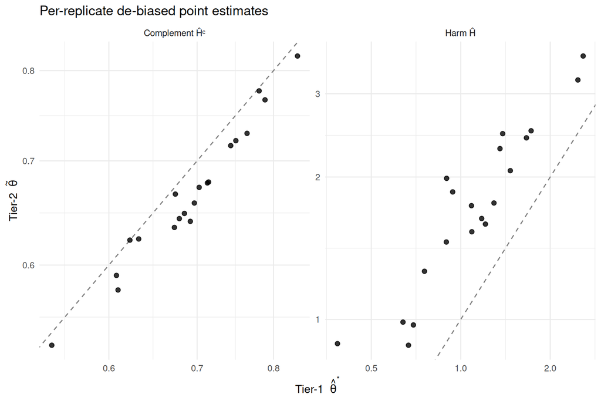

```r
if (run_smoke && !is.null(results)) {
  rd <- results[results$detected == 1, , drop = FALSE]

  # Per-block log-scale agreement (Tier-2 - Tier-1) on point estimate and bounds.
  agree_block <- function(suffix) {
    e1 <- rd[[paste0("t1_", suffix, "_est")]]; e2 <- rd[[paste0("t2_", suffix, "_est")]]
    l1 <- rd[[paste0("t1_", suffix, "_lo")]];  l2 <- rd[[paste0("t2_", suffix, "_lo")]]
    u1 <- rd[[paste0("t1_", suffix, "_hi")]];  u2 <- rd[[paste0("t2_", suffix, "_hi")]]
    ok <- is.finite(e1) & is.finite(e2)
    if (sum(ok) < 2L) return(NULL)
    dpt <- log(e2[ok]) - log(e1[ok])
    dlo <- log(l2[ok]) - log(l1[ok]); dhi <- log(u2[ok]) - log(u1[ok])
    list(
      tab = data.frame(
        Block = if (suffix == "H") "Harm \u0124" else "Complement \u0124\u1d9c",
        Quantity = c("log point", "log CI lower", "log CI upper"),
        mean_d = c(mean(dpt), .mfin(dlo), .mfin(dhi)),
        sd_d   = c(sd(dpt),   .sdfin(dlo), .sdfin(dhi)),
        stringsAsFactors = FALSE),
      n = sum(ok), corr = suppressWarnings(cor(log(e1[ok]), log(e2[ok]))),
      pts = data.frame(block = if (suffix == "H") "Harm \u0124" else "Complement \u0124\u1d9c",
                       t1 = e1[ok], t2 = e2[ok])
    )
  }

  aH <- agree_block("H"); aHc <- agree_block("Hc")
  parts <- Filter(Negate(is.null), list(aH, aHc))

  if (length(parts)) {
    tab <- do.call(rbind, lapply(parts, `[[`, "tab"))
    sub <- paste(vapply(parts, function(p)
      sprintf("%s: %d reps, corr %.3f", sub("  .*", "", p$tab$Block[1]), p$n, p$corr),
      character(1)), collapse = "  \u00b7  ")
    cat(as_raw_html(
      gt(tab, groupname_col = "Block") |>
        tab_header(title = "Tier-2 \u2212 Tier-1 (log scale)", subtitle = sub) |>
        cols_label(mean_d = "Mean \u0394", sd_d = "SD \u0394") |>
        fmt_number(columns = c(mean_d, sd_d), decimals = 4)
    ))

    pts <- do.call(rbind, lapply(parts, `[[`, "pts"))
    p <- ggplot(pts, aes(x = t1, y = t2)) +
      geom_abline(slope = 1, intercept = 0, linetype = 2, colour = "grey50") +
      geom_point(size = 2, alpha = 0.8) +
      scale_x_log10() + scale_y_log10() +
      facet_wrap(~ block, scales = "free") +
      labs(x = expression("Tier-1  "*hat(theta)^"*"),
           y = expression("Tier-2  "*tilde(theta)),
           title = "Per-replicate de-biased point estimates") +
      theme_minimal(base_size = 12)
    print(p)
  } else {
    cat("Too few paired replicates at smoke-test counts to draw the panel.\n")
  }
}
```

# 9 Notes for scale-up